# MUSA 508 Lab 3

Michael Fichman

September 18th, 2020

# Introduction

After uploading the data, we will do some geoprocessing using SF, and then you will undertake two data visualization exercises.

This .rmd document will then be the basis for you to “knit” your own Markdown HTML document, which is the presentation format for your homeworks due next week.

# Setup

## Load Themes

Create your mapping and plotting themes.

Add to these and create color palettes if you please!

```r
mapTheme <- function(base_size = 12) {
  theme(
    text = element_text( color = "black"),
    plot.title = element_text(size = 24,colour = "black"),
    plot.subtitle=element_text(face="italic"),
    plot.caption=element_text(hjust=0),
    axis.ticks = element_blank(),
    panel.background = element_blank(),axis.title = element_blank(),
    axis.text = element_blank(),
    axis.title.x = element_blank(),
    axis.title.y = element_blank(),
    panel.grid.minor = element_blank(),
    panel.border = element_rect(colour = "black", fill=NA, size=2)
  )
}

plotTheme <- function(base_size = 12) {
  theme(
    text = element_text( color = "black"),
    plot.title = element_text(size = 24,colour = "black"),
    plot.subtitle = element_text(face="italic"),
    plot.caption = element_text(hjust=0),
    axis.ticks = element_blank(),
    panel.background = element_blank(),
    panel.grid.major = element_line("grey80", size = 0.1),
    panel.grid.minor = element_blank(),
    panel.border = element_rect(colour = "black", fill=NA, size=2),
    strip.background = element_rect(fill = "grey80", color = "white"),
    strip.text = element_text(size=12),
    axis.title = element_text(size=12),
    axis.text = element_text(size=10),
    plot.background = element_blank(),
    legend.background = element_blank(),
    legend.title = element_text(colour = "black", face = "italic"),
    legend.text = element_text(colour = "black", face = "italic"),
    strip.text.x = element_text(size = 14)
  )
}
```

# Load the data

First step is to clone the repo for the lab 3 data (using github desktop) so we have the data.

You can clone the repo using the “file” tab in Github Desktop and using [this URL:](https://github.com/urbanSpatial/Public-Policy-Analytics-Landing)

[Learn more about embedding links and using bold and italics in markdown here](https://rmarkdown.rstudio.com/authoring_basics.html)

## Read in the data

Notice that this code is a bit different from that in the text. The filepath in the github data is a bit different. Yours will look different too depending on where the data were cloned to (probably your GitHub folder).

```r
lancCounty <- st_read("/Users/penguin/Box Sync/GitHub/Public-Policy-Analytics-Landing/DATA/Chapter2/LancasterCountyBoundary/LancasterCountyBoundary.shp") %>%
  st_transform('ESRI:102728')
uga <- st_read("/Users/penguin/Box Sync/GitHub/Public-Policy-Analytics-Landing/DATA/Chapter2/UGB/Urban_Growth_Boundary.shp") %>%
  st_transform('ESRI:102728')
studyAreaTowns <- st_read("/Users/penguin/Box Sync/GitHub/Public-Policy-Analytics-Landing/DATA/Chapter2/StudyAreaTowns/StudyAreaTowns.shp") %>%
  st_transform('ESRI:102728')
buildings <- st_read("/Users/penguin/Box Sync/GitHub/Public-Policy-Analytics-Landing/DATA/Chapter2/LancasterCountyBuildings/LancasterCountyBuildings.shp") %>% st_transform('ESRI:102728')
greenSpace <- st_read("/Users/penguin/Box Sync/GitHub/Public-Policy-Analytics-Landing/DATA/Chapter2/LancasterCountyGreenSpace/LancasterGreenSpace.shp") %>% st_transform('ESRI:102728')
```

## Exploring our spatial data

Let’s explore these data sets by using commands like `glimpse()`

```r
glimpse(lancCounty)
```

```
## Rows: 1
## Columns: 4
## $ FIPS       <chr> "071"
## $ SHAPE_area <dbl> 27437780098
## $ SHAPE_len  <dbl> 811673.1
## $ geometry   <POLYGON [US_survey_foot]> POLYGON ((2470758 13191.28,...
```

```r
glimpse(uga)
```

```
## Rows: 58
## Columns: 4
## $ TYPE      <chr> "UGB", "UGB", "UGB", "UGB", "UGB", "UGB", "UGB", "UGB", "UG…
## $ MUNI_NAME <chr> "LANCASTER TWP", "MANHEIM TWP", "LANCASTER CITY", "LANCASTE…
## $ UGB_NAME  <chr> "CENTRAL LANCASTER COUNTY", "CENTRAL LANCASTER COUNTY", "CE…
## $ geometry  <MULTIPOLYGON [US_survey_foot]> MULTIPOLYGON (((2361555 -51..., M…
```

```r
glimpse(studyAreaTowns)
```

```
## Rows: 32
## Columns: 2
## $ MUNI     <chr> "LANCASTER TOWNSHIP", "LANCASTER TOWNSHIP", "LANCASTER TOWNS…
## $ geometry <MULTIPOLYGON [US_survey_foot]> MULTIPOLYGON (((2381542 -47..., MU…
```

```r
glimpse(buildings)
```

```
## Rows: 269,104
## Columns: 9
## $ EDITOR     <chr> "TRI", "TRI", "TRI", "TRI", "TRI", "TRI", "TRI", "TRI", "T…
## $ UPDATE_TYP <chr> "No Change", "No Change", "No Change", "No Change", "No Ch…
## $ YEAR       <int> 2001, 2001, 2001, 2001, 2001, 2001, 2001, 2001, 2001, 2001…
## $ UPDATE_DAT <date> 2013-06-29, 2013-06-29, 2013-06-29, 2013-06-29, 2013-06-2…
## $ SPEC       <int> 1, 0, 0, 0, 0, 0, 0, 0, 0, 0, 0, 0, 1, 0, 0, 0, 0, 0, 0, 1…
## $ HEIGHT     <dbl> 0.00, 22.86, 0.00, 0.00, 28.18, 31.93, 0.00, 0.00, 0.00, 0…
## $ SHAPE_area <dbl> 315.7225, 1248.0215, 1331.5759, 2083.4788, 3242.2714, 2105…
## $ SHAPE_len  <dbl> 72.90203, 150.83361, 168.36831, 184.39047, 292.30643, 208.…
## $ geometry   <MULTIPOLYGON [US_survey_foot]> MULTIPOLYGON (((2366746 -48..., …
```

```r
glimpse(greenSpace)
```

```
## Rows: 2,397
## Columns: 3
## $ ID       <dbl> 1, 2, 3, 4, 5, 6, 7, 8, 9, 10, 11, 12, 13, 14, 15, 16, 17, 1…
## $ GRIDCODE <dbl> 1, 1, 1, 1, 1, 1, 1, 1, 1, 1, 1, 1, 1, 1, 1, 1, 1, 1, 1, 1, …
## $ geometry <POLYGON [US_survey_foot]> POLYGON ((2386153 -11445.34..., POLYGON…
```

What do you find? What kind of data are these?

Make some simple ggplots with `geom_sf` by mapping the municipalities, the Lancaster County Boundary and the UGA and put them in a chunk right here:

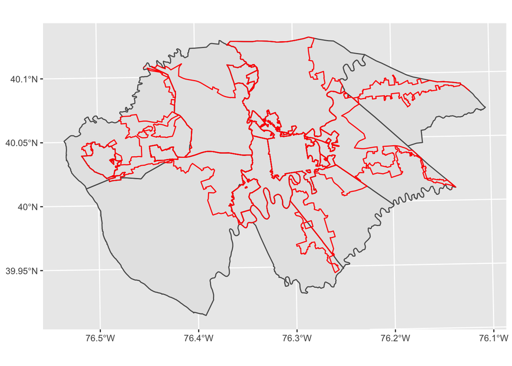

```r
ggplot() +
  geom_sf(data = studyAreaTowns) +
  geom_sf(data = uga, fill = 'transparent' , color = 'red')
```

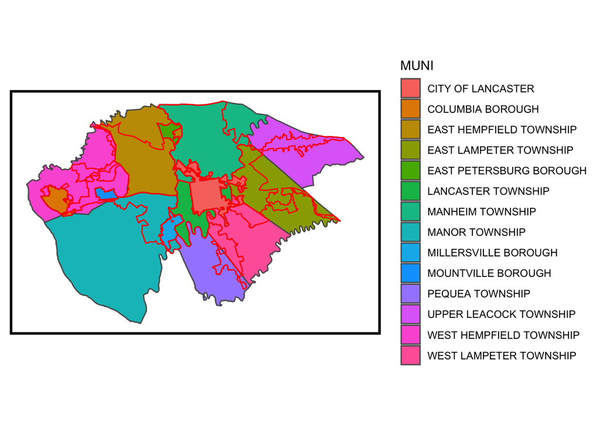

```r
ggplot() +
  geom_sf(data = studyAreaTowns, aes(fill = MUNI)) +
  geom_sf(data = uga, fill = 'transparent' , color = 'red') +
  mapTheme()
```

# Geoprocessing

We are going to do some meat-and-potatoes vetor GIS - union and buffer.

## Union

Merging all the shapes (the `st_buffer(1)` just consolidates fragmented geometries)

```r
uga_union <-
  st_union(uga) %>%
  st_buffer(1) %>%
  st_sf()
```

## Outside and inside buffers

We create our `outsideBuffer`, our `insideBuffer` and then we `rbind` the buffers together.

What is `rbind` doing? What are the conditions that allow it to work?

```r
outsideBuffer <-
  st_buffer(uga_union, 660) %>%
  st_difference(uga_union) %>%
  mutate(Legend = "Outside")


insideBuffer <-
  st_buffer(uga_union, dist = -660) %>%
  st_difference(uga_union, .) %>%
  mutate(Legend = "Inside")

bothBuffers <- rbind(insideBuffer, outsideBuffer)
```

# Map the buffers

Here is a basic plot of the buggers that we have created.

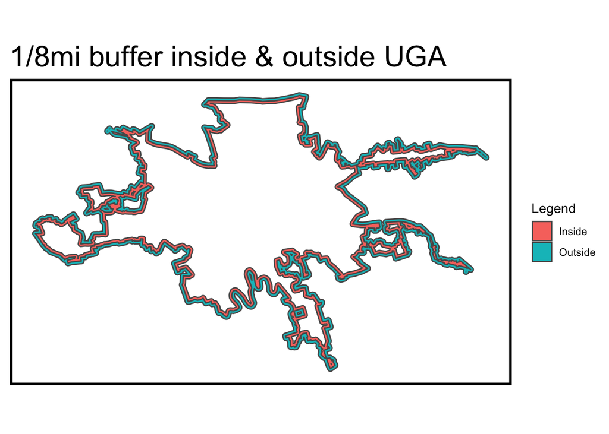

```r
ggplot() +
  geom_sf(data = bothBuffers, aes(fill = Legend)) +
  scale_fill_manual(values = c("#F8766D", "#00BFC4")) +
  labs(title = "1/8mi buffer inside & outside UGA") +
  mapTheme()
```

# Join the Town info to the buffers

```r
buffersAndTowns <-
  st_intersection(st_make_valid(studyAreaTowns), bothBuffers) %>%
  filter(MUNI != "MOUNTVILLE BOROUGH")
```

# Mapping Challenge 1

Find a way to map the inside and outside buffers nicely that distinguishes them from each other AND shows the municipalities they belong to. Try manipulating the colors (remember our palettes, and the `viridis` package? remember `scale_fill_manual`). Add geographic context. Add legends and titles and subtitles.

Consider how you might label objects in your map using

`geom_sf_text(data = studyAreaTowns, aes(label = MUNI), size = 3)`

Think about ways to manipulate the `studyAreaTowns` data inside that text geom to make it more legible.

Put all this code into your a markdown chunk that runs correctly and allows this markdown to `knit`. Then see if you can manipulate the chunk options so that there aren’t annoying warnings and other messages you don’t want showing up in an assignment.

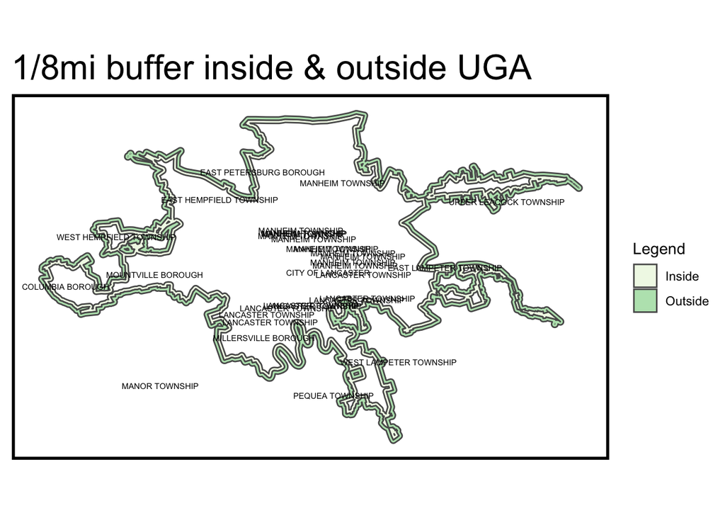

```r
palette5 <- c("#f0f9e8","#bae4bc","#7bccc4","#43a2ca","#0868ac")

ggplot() +
  geom_sf(data = bothBuffers, aes(fill = Legend)) +
  scale_fill_manual(values = palette5) +
  labs(title = "1/8mi buffer inside & outside UGA") +
  geom_sf_text(data = studyAreaTowns, aes(label = MUNI), size = 2) +
  mapTheme()
```

# Mapping Challenge 2

…. if time allows…

Download Lancaster County Data from the US Census and notice that we find the area in square feet (which is the linear unit of our projection).

Take that and turn it into a measure of persons per square mile.

```r
tracts17 <-
  get_acs(geography = "tract", variables = c("B25026_001E","B25058_001E"),
          year=2017, state=42, county="Lancaster", geometry=T, output="wide") %>%
  st_transform('ESRI:102728') %>%
  rename(TotalPop = B25026_001E,
         MedRent = B25058_001E) %>%
  dplyr::select(-NAME, -starts_with("B")) %>%
  mutate(area_sqFt = (as.numeric(st_area(.))))
```

Do a centroid join to keep just the tracts inside the UGB - OR - figure out a way to just keep tracts that intersect the UGB (see the code from the TOD chapter).

```r
insideTracts <- st_centroid(tracts17)[studyAreaTowns,] %>%
  st_drop_geometry() %>%
  left_join(dplyr::select(tracts17, GEOID)) %>%
  st_sf()
```

```
## Warning in st_centroid.sf(tracts17): st_centroid assumes attributes are constant
## over geometries of x
```

Make a map of population density in Lancaster - either within the UGB, or as it relates to proximity to the UGB, or at the county level generally. Do you want to use the quartile functions from last week? If so, you need to add those as chunks in your markdown and run them.

Put that map in a code chunk and render it in a markdown that knits correctly and doesn’t have wacky messages and warnings.